# HW4-shiyuchen-21210980116

Shi Yuchen

4/4/2022

## Newton-Raphson 算法逻辑回归

```r
library(stringr)
library(ggplot2)
library(ggpubr)
library(tidyr)
library(dplyr)
```

Question: Write Newton-Raphson algorithm to estimate logistic regression by yourself.

1. Generate $X<-\left(1, X_{1}, X_{2}, X_{3}\right)$, where $X_{j} \sim N\left(0, I_{N}\right)$.
2. Set true parameter $\beta<-(-1,2,-3,0.5)^{\top}$.
3. Set $N<-200,400,800,1600$.
4. Estimate $\beta$ using $N R$ algorithm for $R<-200$ times. For each $j$, draw $\left(\widehat{\beta}_{j}^{(r)}-\beta_{j}\right)$ in boxplot for $N<-200,400,800,1600$.

Submit your code (with detailed comments) + report your plot & findings in html.

```r
get.p <- function(x, beta) {
  a <- exp(x %*% beta)
  a / (1+a)
}
get.w <- function(x, beta) {
  p <- get.p(x, beta)
  diag(c(p * (1-p)))
}
```

```r
set.seed(116)

R <- 200  # 重复实验次数
N <- 200  # 样本数量
iter.times <- 100 # NR迭代次数


# NR 法进行参数估计
nr.algo <- function(x, y, beta, iters=100, threshold=1e-10) {
  for (i in 1:iters) {
    # NR 迭代过程
    p <- get.p(x, beta)
    w <- get.w(x, beta)
    # p <- plogis(x %*% beta)
    # w <- diag(c(N*p * (1-p)))
    beta.old <- beta
    beta <- beta + solve(t(x) %*% w %*% x) %*% t(x) %*% (y - p);
    # cat(beta, "\n")

    # 异常检查, 终止条件
    delta <- mean((beta-beta.old) ** 2)
    if (is.na(delta)) {
      cat("Encounter NA at iteration", i, "!\n")
      return(beta)
    }
    if (delta <= threshold) {
      # cat("Early stop after", i, "iterations!\n")
      return(beta)
    }
  }
  # cat("Finish!\n")
  return(beta)
}

# 模拟进行实验
nr.experiment <- function(beta.true, iters=iter.times) {
  # 生成数据
  X <- matrix(c(
    array(1, c(N, 1)),
    array(rnorm(3*N), c(N, 3))
  ), ncol=4)

  # 注意, 这里应该按照按照 伯努利分布生成Y
  # Y <- as.integer(plogis(X %*% beta.true) > .5)
  probs <- get.p(X, beta.true)
  # probs <- plogis(X %*% beta.true)
  Y <- rbinom(n=length(probs), size=1, prob=probs)

  beta.0 <- matrix(rnorm(4, mean = 0, sd = .2)) # 初始值; 注意调整 sd!
  beta.e <- nr.algo(X, Y, beta.0, iters=iters)
  c(beta.e)
}

# beta.true <- matrix(c(-1,2,-3,0.5))
# # 保存结果
# beta.estimates <- matrix(nrow = R, ncol = 4)
#
# for (i in 1:R) {
#   beta.e <- nr.experiment(beta.true)
#
#   beta.estimates[i,] <- t(beta.e)
# }
```

```r
# 真实参数
beta.true <- matrix(c(-1,2,-3,0.5))

# 重复运行实验, 保存记录, 绘图
nr.plot <- function(N) {
  beta.estimates <- matrix(nrow = R, ncol = 4) # # 保存结果
  # 运行R次实验
  for (i in 1:R) {
    beta.e <- nr.experiment(beta.true)
    beta.estimates[i,] <- t(beta.e)
  }
  # 绘图
  df <- data.frame(beta.estimates) %>%  pivot_longer(1:4,
       names_to = "beta",
       values_to = "estimate")

  ggplot(data.frame(df)) +
    geom_boxplot(aes(x=beta, y=estimate), na.rm = T, fill="gray",) +
    labs(x="beta", y = "estimated", title=bquote(N==.(N))) +
    theme_bw() +
    theme(panel.border=element_blank(),
          text = element_text(family = "STXihei"),
          axis.title = element_text(size = 15),
          axis.text = element_text(size = 11))
}
```

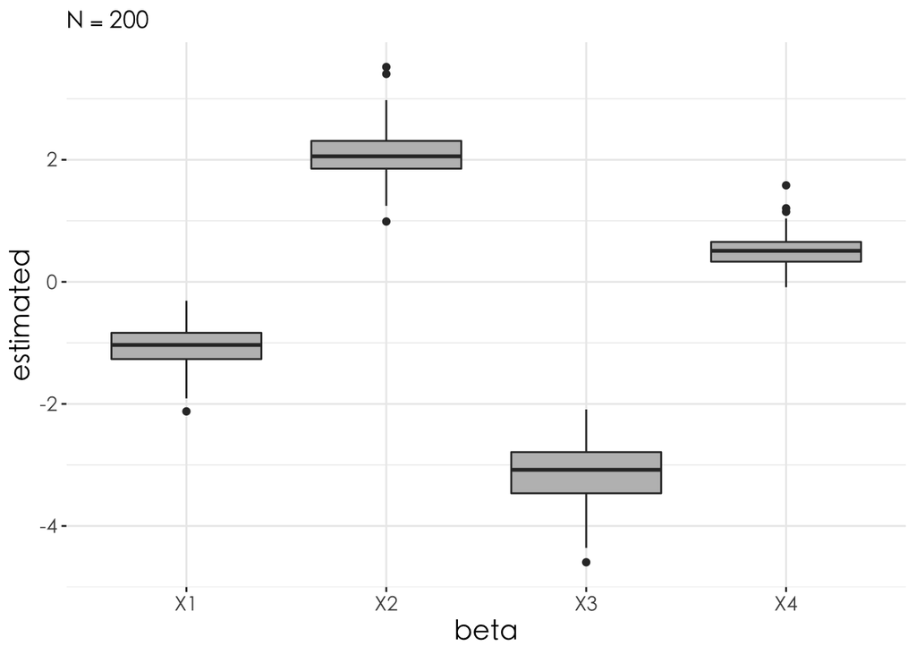

```r
# N.list <-  c(200,400,800,1600)
# for (r in N.list) {
#   nr.plot(r)
# }
# f <- function(x) {
#   for (i in 1:10) {
#     cat(i)
#     if (i==5) {
#       return(i)
#     }
#   }
# }
# f()
nr.plot(200)
```

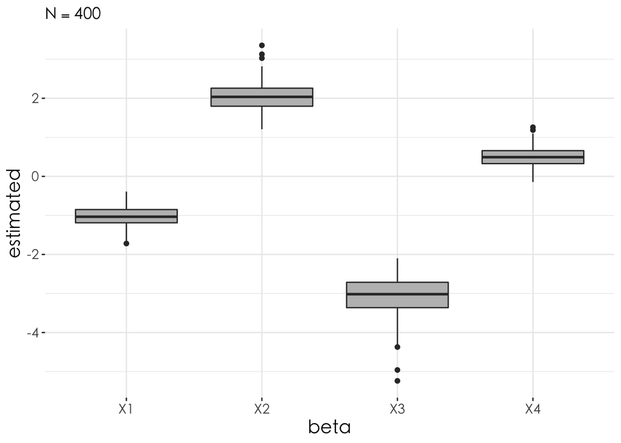

```r
nr.plot(400)
```

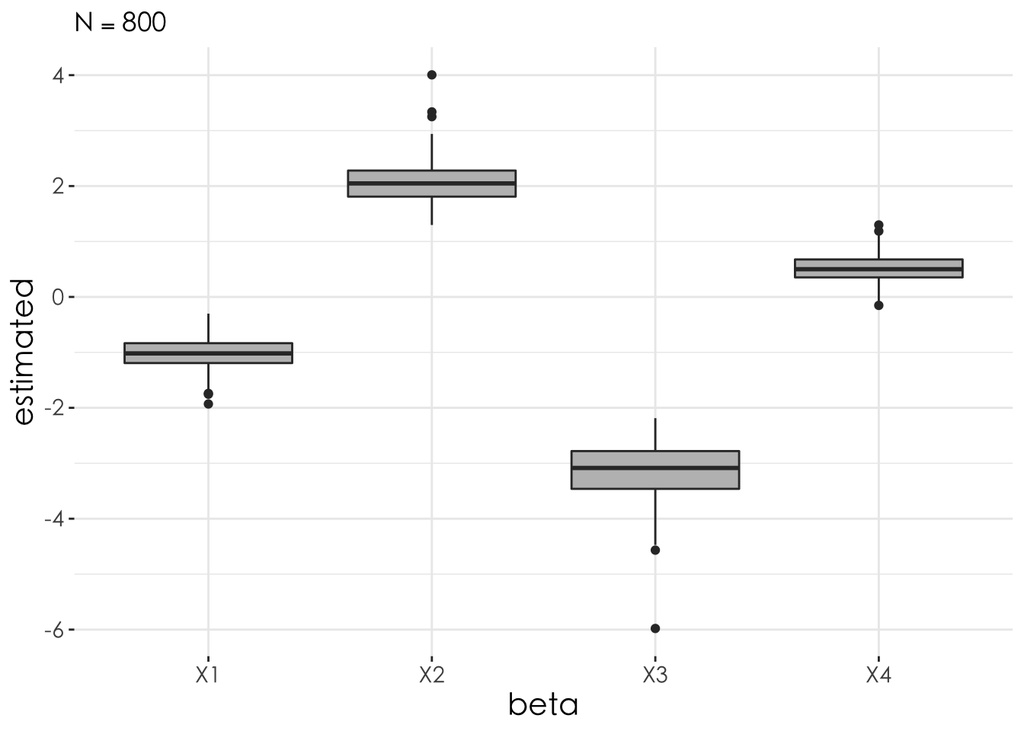

```r
nr.plot(800)
```

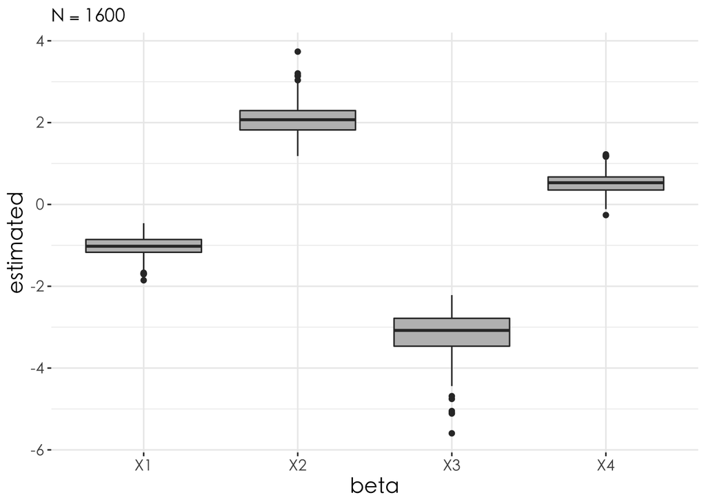

```r
nr.plot(1600)
```

## 数据说明

互联网的出现和扩张，改变了人们的生活。其中之一，就是为术业有专攻的人们提供了发光发热的新方式。本案例将探索这股知识网红热潮中的一个分支，如何通过一对一聊天的方式来建立自己的职业声誉。我们选取了知识共享网站在行上的行家约聊数据，探索了行家受欢迎程度的分布特征和影响因素，并根据数据分析的结果为想要进入这个领域的专业人士提供了自我包装的建议。数据共分为四个文件，“D-cate.csv”为话题分类，“D-mentor.csv”为行家属性，“D-topic.csv”为话题属性、“D-comment.csv”为用户评价信息。由于变量较多，具体变量含义请参照“REDAME.txt”。

```r
library(stringr)
library(ggplot2)
library(ggpubr)
library(dplyr)
```

## 分析任务

1. 读入数据：
1. 读入所有话题的分类属性D-cate.csv，命名为cate
2. 读入行家属性D-mentor.csv，命名为mentor
3. 读入话题属性D-topic.csv，命名为topic
4. 读入用户对话题做出的评价D-comment.csv，命名为comment

```r
cate <- read.csv("D-cate.csv")
mentor <- read.csv("D-mentor.csv")
topic <- read.csv("D-topic.csv")
comment <- read.csv("D-comment.csv")
```

2. 数据处理：
1. 将以下变量转化为因子型

对mentor表中的行家接受率arating，设置高接受率、中接受率、其他共三个水平； 对mentor表中的行家回应邀约时间react_tm，设置半天内回应、1天内回应、2天内回应、其他共四个水平； 对topic表中的话题约见城市topic_city，设置北京、上海、深圳、广州、杭州、成都、武汉、西安、宁波、其他共10个水平。

2. 构造变量：

在topic表中增加9个0-1变量：d1-d9，分别对应心理、投资理财、职场发展、教育学习、创业和融资、生活服务、互联网+、兴业经验、其他共9个话题； 在topic中增加0-1变量：is_ord，话题是否成交（topic_ordcnt>0）； 在topic中增加0-1变量：is_fst，话题是否发生在北上深； topic中增加话题价格带：price_b，分为<<-300、(300,600]、(600,1000)、1000+四个水平； 对price_b因子化，并设定各取值的顺序； topic表中增加话题描述长度：len_desc，话题描述字符数，划分为(0,200]、(200,400]、(400,600]、(600,800]、(800,1000]、1000+六个水平； topic表中增加行家是否回复用户评价：is_rpl，行家是否回复用户评价（聚合comment表中is_reply得到reply_cnt，reply_cnt>0）。

```r
# table(mentor$arating)
idx <- mentor$arating %in% c("高接受率", "中接受率")
mentor$arating[!idx] <- "其他"
mentor$arating <- factor(mentor$arating, levels = c("高接受率", "中接受率", "其他"))
# table(mentor$react_tm)
mentor$react_tm <- factor(mentor$react_tm, levels = c("半天内回应", "1天内回应", "2天内回应", "其他"))

# table(topic$topic_city)
topic$topic_city <- factor(topic$topic_city)
```

```r
topic$d1 <- ifelse(str_detect(topic$topic_tag, "心理"), TRUE, FALSE)
# table(topic$tag_xinli)
topic$d2 <- ifelse(str_detect(topic$topic_tag, "投资理财"), TRUE, FALSE)
topic$d3 <- ifelse(str_detect(topic$topic_tag, "职场发展"), TRUE, FALSE)
topic$d4 <- ifelse(str_detect(topic$topic_tag, "教育学习"), TRUE, FALSE)
topic$d5 <- ifelse(str_detect(topic$topic_tag, "创业和投融资"), TRUE, FALSE)
topic$d6 <- ifelse(str_detect(topic$topic_tag, "生活服务"), TRUE, FALSE)
topic$d7 <- ifelse(str_detect(topic$topic_tag, "互联网+"), TRUE, FALSE)
topic$d8 <- ifelse(str_detect(topic$topic_tag, "行业经验"), TRUE, FALSE)
# paste0("d", 1:8)
# "d1" "d2" "d3" "d4" "d5" "d6" "d7" "d8"
idx <- apply(topic[paste0("d", 1:8)], 1, sum)==0
topic$d9 <- ifelse(idx, TRUE, FALSE)

topic$is_ord <- topic$topic_ordcnt>0

topic$is_fst <- topic$topic_city %in% c("北京", "上海", "深圳")
# table(topic$is_fst)

topic$price_b <- cut(topic$price, breaks = c(0, 300, 600, 1000, 1e10), labels = c("<=300", "(300,600]", "(600,1000]", "1000+"))
# table(topic$price_b)

topic$len_desc <- cut(
  str_length(topic$topic_desc), breaks = c(0, 200, 400, 600, 800, 1000, 1e10),
  labels = c("(0,200]", "(200,400]", "(400,600]", "(600,800]", "(800,1000]", "1000+"))

comment.topic <- comment %>% group_by(topic_id) %>% summarise(rep.cnt=sum(is_reply))
topic <- left_join(topic, comment.topic, by="topic_id")
topic$is_rpl <- topic$rep.cnt > 0
```

3. 绘制导师约见人数分布直方图（可以考虑对mentor$mentor_ordcnt做对数变换），并进行描述分析

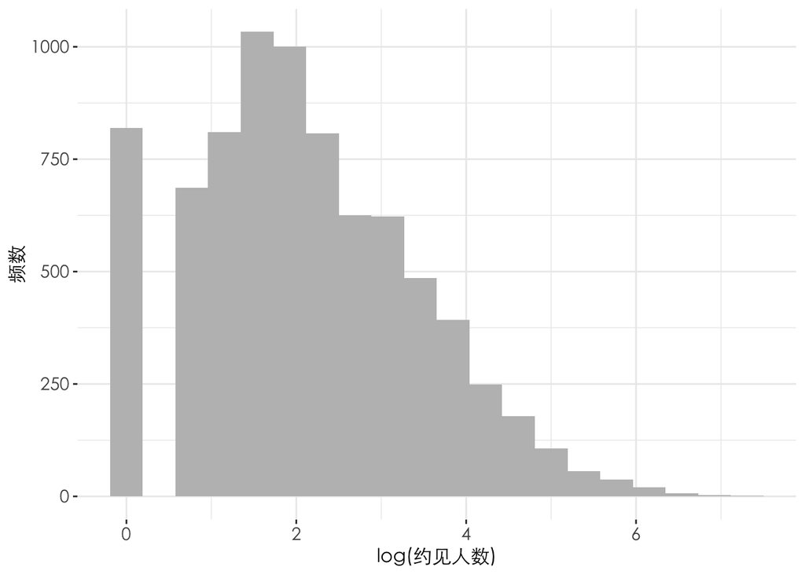

```r
ggplot(mentor) +
    geom_histogram(aes(x = log(mentor_ordcnt+1)), bins = 20, fill = "gray") +
    labs(y = "频数", x = "log(约见人数)") +
    theme_bw() +
    theme(panel.border=element_blank(),
          text = element_text(family = "STXihei"),
          axis.title = element_text(size = 12),
          axis.text = element_text(size = 11))
```

对于导师约见人数做对数变换, 绘制频次直方图 (为计算合法, 将约见人数+1). 从上图可以看到, 有750+的导师约见人数为0, 多数导师的对数约见人数在 [0, 4] 范围内, 也即50人以下; 对数约见人数呈现长尾分布.

4. 分领域（心理、投资理财等共9个领域）绘制行家约见人数（topic_ordcnt）的箱线图，按中位数从左到右，从高到低的顺序排列，并进行描述分析

```r
col.names <- paste0("d", 1:9)
districts <- c("心理", "投资理财", "职场发展", "教育学习", "创业和投融资", "生活服务", "互联网+", "行业经验", "其他")

# # 分开画图
# plots.list <- vector('list', 9)
# for (i in 1:9) {
#   col.name <- col.names[i]
#   plots.list[[i]] <- ggplot(topic[topic[[col.name]], ]) +
#     geom_boxplot(aes(y = log(topic_ordcnt+1)), varwidth = TRUE, fill = "grey") +
#     labs(x = districts[i], y = "")+
#     theme_bw() +
#     theme(panel.border=element_blank(),
#           text = element_text(family = "STXihei"),
#           axis.title = element_text(size = 13),
#           axis.text = element_text(size = 12))
# }
# # plots.list[[1]]
# ggarrange(plotlist = plots.list)
```

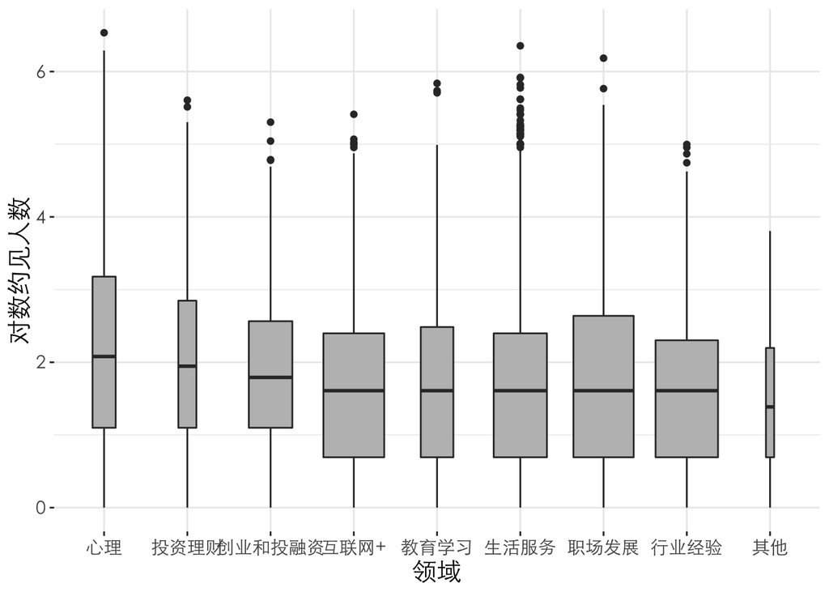

```r
topic.districs <- lapply(1:9, function(i) {
  col.name <- col.names[i]
  d2 <- topic[, c("topic_ordcnt", col.name)][topic[[col.name]],]
  d2$type = districts[i]
  colnames(d2) = c("topic_ordcnt", "none", "type")
  return(d2)
}) %>% do.call('rbind', .)

# 按照中位数对于领域进行排序
median.order <- topic.districs %>% group_by(type) %>% summarise(ordcnt_median=median(topic_ordcnt))
median.order <- median.order[order(median.order$ordcnt_median, decreasing = TRUE),]
topic.districs$type <- factor(topic.districs$type, levels = median.order$type) # 转为 factor
ggplot(topic.districs) +
  geom_boxplot(aes(type, log(topic_ordcnt+1)), fill="gray", varwidth=TRUE) +
  labs(x="领域", y = "对数约见人数") +
  theme_bw() +
  theme(panel.border=element_blank(),
        text = element_text(family = "STXihei"),
        axis.title = element_text(size = 15),
        axis.text = element_text(size = 11))
```

一个 topic 所属的领域可能有多个. 为了对于之前定义的多个 0-1 变量的「领域」绘图, 制作中间表格 topic.districs, 将领域作为一个类别变量, 约见人数可以出现在多行. 然后根据约见人数的中位数排序绘制箱线图如上.

从上图可以看到, 平均而言, 所选的8个类别相较于其他的领域有着更高的约见人数; 其中, 心理、投资理财、创业和投融资这三个领域的约见人数平均更多.

5. 绘制不同邀约接受率（arating）、不同响应时长（react_tm）、是否回复评价（is_rp）和话题约见人数（topic_ordcnt）的箱线图，并进行描述分析

```r
topic.mentor <- left_join(topic, mentor, by=c("mentor_id"))
# colnames(topic.mentor)
topic.mentor$ordcnt.log <- log(topic.mentor$topic_ordcnt+1)

reply.table <- comment %>% group_by(topic_id) %>% summarise(reply.mean=mean(is_reply))
# summary(reply.table)
# 较多的评论是没有回复的, 因此将分组聚合之后, 有回复的topic的is.rp属性设置为TRUE
reply.table$is.rp <- reply.table$reply.mean>0
topic.mentor.comment <- left_join(topic.mentor, reply.table, by=c("topic_id"))
# summary(topic.mentor.comment)
```

[output not shown]

[output cut: 28 more lines]

[output not shown]

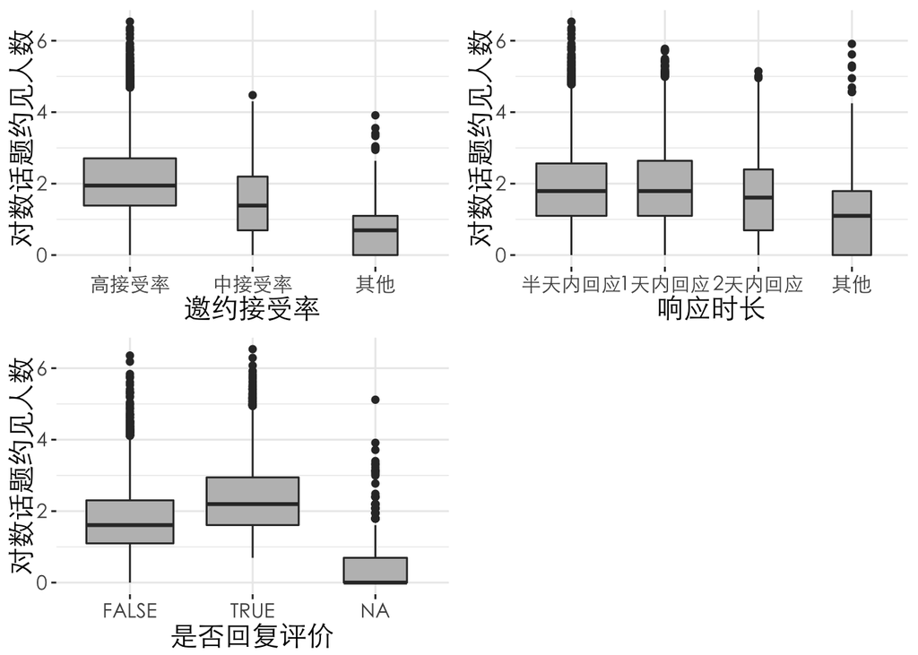

```r
box.arating <- ggplot(topic.mentor) +
  geom_boxplot(aes(arating, ordcnt.log), fill="gray", varwidth=TRUE) +
  labs(x="邀约接受率", y = "对数话题约见人数") +
  theme_bw() +
  theme(panel.border=element_blank(),
        text = element_text(family = "STXihei"),
        axis.title = element_text(size = 15),
        axis.text = element_text(size = 11))
box.react <- ggplot(topic.mentor) +
  geom_boxplot(aes(react_tm, ordcnt.log), fill="gray", varwidth=TRUE) +
  labs(x="响应时长", y = "对数话题约见人数") +
  theme_bw() +
  theme(panel.border=element_blank(),
        text = element_text(family = "STXihei"),
        axis.title = element_text(size = 15),
        axis.text = element_text(size = 11))

box.isrp <- ggplot(topic.mentor.comment) +
  geom_boxplot(aes(is.rp, ordcnt.log), fill="gray", varwidth=TRUE) +
  labs(x="是否回复评价", y = "对数话题约见人数") +
  theme_bw() +
  theme(panel.border=element_blank(),
        text = element_text(family = "STXihei"),
        axis.title = element_text(size = 15),
        axis.text = element_text(size = 11))
# box.isrp

ggarrange(box.arating, box.react, box.isrp)
```

分别绘制邀约接受率（arating）、不同响应时长（react_tm）、是否回复评价（is_rp）和话题约见人数（topic_ordcnt）的箱线图. 因此, 主表为 topic 表, 接受率和相应时长通过连接 mentor 得到; 对于是否回复评论, 需要分组聚合 comment 表, 这里将一个 topic的所有评论中, 只要有一个回复就认为此 topic 进行了回复. 三个箱线图绘制如上.

可以看到, 1) 接受率较高的topic有着较多的话题约见人数; 2) 响应时长也和话题约见人数有关, 半天和1天内回应的topic有着较高的约见人数; 3) 有回复评论的topic一般有着较高的约见人数, 此图中的NA表示该topic没有评论, 可以看到这些topic的约见人数也较低, 这是符合常识的.

6. 根据comment表中信息，绘制各行业用户数量柱状图并进行描述分析

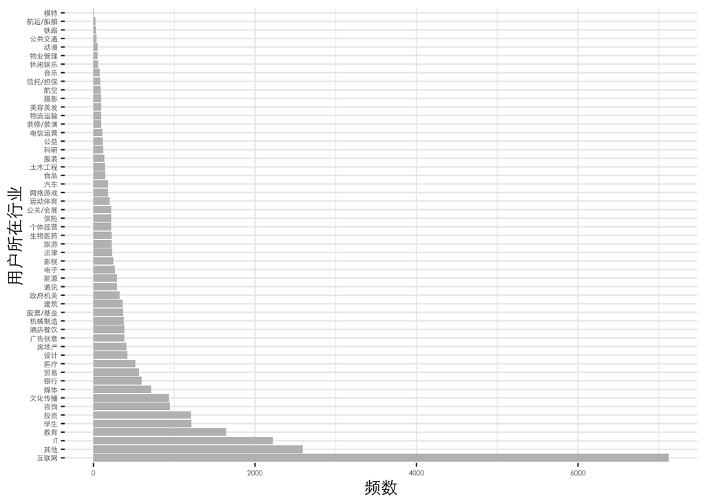

```r
# 去除NA
comment.nna <- comment[!is.na(comment$user_industry_name), ]
# 统计各个行业用户数
user.industry.cnt <- comment.nna %>% group_by(user_industry_name) %>%
  summarise(count=length(unique(user_id)))
# 排序
user.industry.cnt <- user.industry.cnt[order(user.industry.cnt$count, decreasing = TRUE),]
user.industry.cnt$user_industry_name <- factor(user.industry.cnt$user_industry_name, levels = user.industry.cnt$user_industry_name)
# 柱状图
# bar1 <- ggplot(user.industry.cnt[1:10, ]) +
#     geom_bar(aes(x=user_industry_name, y=(count)), fill = "gray", stat= 'identity') +
#     labs(y = "频数", x = "用户所在行业") +
#     theme_bw() +
#     ylim(0,8000) +
#     theme(panel.border = element_blank(),
#           text = element_text(family = "STXihei"),
#           axis.title = element_text(size = 12),
#           axis.text = element_text(size = 8))
# bar2 <- ggplot(user.industry.cnt[45:53, ]) +
#     geom_bar(aes(x=user_industry_name, y=(count)), fill = "gray", stat= 'identity') +
#     labs(y = "频数", x = "用户所在行业") +
#     theme_bw() +
#     ylim(0,8000) +
#     theme(panel.border = element_blank(),
#           text = element_text(family = "STXihei"),
#           axis.title = element_text(size = 12),
#           axis.text = element_text(size = 8))
# ggarrange(plotlist = list(bar1, bar2))
ggplot(user.industry.cnt) +
    geom_bar(aes(x=user_industry_name, y=count), fill = "gray", stat = 'identity') +
    labs(y = "频数", x = "用户所在行业") +
    coord_flip() +
    theme_bw() +
    theme(panel.border = element_blank(),
          text = element_text(family = "STXihei"),
          axis.title = element_text(size = 12),
          axis.text = element_text(size = 5))
```

对于用户所在行业进行分类, 统计用户数量, 绘制柱状图如上. 可以看到, 行业最多的是互联网, 用户数量超过了7000人, 其次是IT、教育、学生、投资等, 均超过了1000人; 长尾行业较多.

```r
summary(topic.mentor.comment)
```

```
##     topic_id          topic_city    topic_url           mentor_id
##  Min.   :29859496   北京   :7223   Length:13797       Min.   :84743794
##  1st Qu.:29866756   上海   :2773   Class :character   1st Qu.:84777980
##  Median :29872153   深圳   :1421   Mode  :character   Median :84838064
##  Mean   :29871885   广州   : 749                      Mean   :84898872
##  3rd Qu.:29877835   杭州   : 636                      3rd Qu.:85002565
##  Max.   :29882464   成都   : 402                      Max.   :85277105
##                     (Other): 593
##      type               price             disprice         score
##  Length:13797       Min.   :     1.0   Min.   : 60.0   Min.   :7.000
##  Class :character   1st Qu.:   300.0   1st Qu.:150.0   1st Qu.:9.200
##  Mode  :character   Median :   499.0   Median :200.0   Median :9.300
##                     Mean   :   541.4   Mean   :199.4   Mean   :9.282
##                     3rd Qu.:   521.0   3rd Qu.:249.0   3rd Qu.:9.500
##                     Max.   :200000.0   Max.   :500.0   Max.   :9.900
##                                        NA's   :13397   NA's   :6279
##   topic_name          duration          topic_ordcnt     topic_tag
##  Length:13797       Length:13797       Min.   :  0.00   Length:13797
##  Class :character   Class :character   1st Qu.:  1.00   Class :character
##  Mode  :character   Mode  :character   Median :  4.00   Mode  :character
##                                        Mean   : 10.68
##                                        3rd Qu.: 11.00
##                                        Max.   :687.00
##
##   topic_desc            d1              d2              d3
##  Length:13797       Mode :logical   Mode :logical   Mode :logical
##  Class :character   FALSE:13310     FALSE:13501     FALSE:10499
##  Mode  :character   TRUE :487       TRUE :296       TRUE :3298
##
##
##
##
##      d4              d5              d6              d7
##  Mode :logical   Mode :logical   Mode :logical   Mode :logical
##  FALSE:12830     FALSE:12077     FALSE:11222     FALSE:10433
##  TRUE :967       TRUE :1720      TRUE :2575      TRUE :3364
##
##
##
##
```

[output cut: 33 more lines]

```
##  Length:13797       Length:13797       Length:13797       Min.   :0.0000
##  Class :character   Class :character   Class :character   1st Qu.:0.6931
##  Mode  :character   Mode  :character   Mode  :character   Median :1.6094
##                                                           Mean   :1.7078
##                                                           3rd Qu.:2.4849
##                                                           Max.   :6.5338
##
##    reply.mean       is.rp
##  Min.   :0.0000   Mode :logical
##  1st Qu.:0.0000   FALSE:5215
##  Median :0.0667   TRUE :5833
##  Mean   :0.2850   NA's :2749
##  3rd Qu.:0.5000
##  Max.   :1.0000
##  NA's   :2749
```

```r
user.industry.cnt
```

```
## # A tibble: 53 × 2
##    user_industry_name count
##    <fct>              <int>
##  1 互联网              7122
##  2 其他                2588
##  3 IT                  2222
##  4 教育                1640
##  5 学生                1216
##  6 投资                1210
##  7 咨询                 947
##  8 文化传播             931
##  9 媒体                 716
## 10 银行                 597
## # … with 43 more rows
```

```r
head(topic)
```

```
##   topic_id topic_city                                           topic_url
## 1 29859496       北京 http://www.zaih.com/mentor/84743795/topic/29859496/
## 2 29859497       北京 http://www.zaih.com/mentor/84743796/topic/29859497/
## 3 29859501       北京 http://www.zaih.com/mentor/84743825/topic/29859501/
## 4 29859502       北京 http://www.zaih.com/mentor/84743825/topic/29859502/
## 5 29859503       北京 http://www.zaih.com/mentor/84743837/topic/29859503/
## 6 29859504       北京 http://www.zaih.com/mentor/84743837/topic/29859504/
##   mentor_id type price disprice score                         topic_name
## 1  84743795 组团   400       NA    NA                       摄影入门指导
## 2  84743796 通话  1500       NA   9.6             私人定制理性的护肤指南
## 3  84743825        599       NA   9.5 「产品经理」职业目标梳理及发展规划
## 4  84743825       1000       NA   9.3 创业公司如何规划产品业务与团队管理
## 5  84743837 通话    98       NA   9.5       职场成长的学识养成与实践积累
## 6  84743837 通话    99       NA   9.4       把自己的兴趣打造为核心竞争力
##   duration topic_ordcnt         topic_tag
```

[output cut: 27 more lines]

```r
summary(comment)
```

```
##     topic_id          comment_id     likings_count        score
##  Min.   :29859496   Min.   :     2   Min.   : 0.000   Min.   :0.000
##  1st Qu.:29863519   1st Qu.: 35902   1st Qu.: 0.000   1st Qu.:9.100
##  Median :29868679   Median : 71096   Median : 0.000   Median :9.300
##  Mean   :29869126   Mean   : 70152   Mean   : 0.363   Mean   :8.866
##  3rd Qu.:29874329   3rd Qu.:105050   3rd Qu.: 0.000   3rd Qu.:9.500
##  Max.   :29882447   Max.   :135007   Max.   :71.000   Max.   :9.900
##
##  reviews_count      duration_1     service_type          user_id
##  Min.   :  1.00   Min.   : 30.00   Length:107687      Min.   :84743799
##  1st Qu.:  9.00   1st Qu.: 60.00   Class :character   1st Qu.:84811883
##  Median : 21.00   Median : 60.00   Mode  :character   Median :84922149
##  Mean   : 43.77   Mean   : 80.74                      Mean   :84967066
##  3rd Qu.: 48.00   3rd Qu.: 90.00                      3rd Qu.:85118036
##  Max.   :378.00   Max.   :180.00                      Max.   :85278426
##
##   user_city         user_is_tutor   user_industry_id user_industry_name
##  Length:107687      Mode :logical   Min.   : 2.00    Length:107687
##  Class :character   FALSE:97162     1st Qu.: 2.00    Class :character
##  Mode  :character   TRUE :10525     Median :15.00    Mode  :character
##                                     Mean   :25.03
##                                     3rd Qu.:49.00
##                                     Max.   :63.00
##                                     NA's   :37569
##    mentor_id           is_reply
##  Min.   :84743794   Min.   :0.000
##  1st Qu.:84766076   1st Qu.:0.000
##  Median :84800016   Median :0.000
##  Mean   :84850299   Mean   :0.243
##  3rd Qu.:84903022   3rd Qu.:0.000
##  Max.   :85273156   Max.   :1.000
##
```

7. 使用is_ord作为因变量Y，自变量选择话题价格、话题价格带、想见行家用户数、行家约见人数、话题持续时长、话题所在城市、行家回复邀约的时长、行家接受约见的比率、话题长度、话题是否在北上广以及所属行业进行建模。使用AIC进行模型选择，绘制ROC曲线并计算AUC。

```r
# data.full <- left_join(topic.mentor.comment, cate, by=c("topic_id"))
# summary(data.full)
# summary(topic.mentor.comment)

# 划分数据集
data.full <- topic.mentor.comment
set.seed(116)    # 随机数种子
idx <- sample(x = dim(data.full)[1], size = dim(data.full)[1]/5, replace = F)
data.train <- data.full[-idx,]
data.test <- data.full[idx,]
```

```r
glm.fit0 = glm(
  is_ord ~ price+price_b+heart+mentor_ordcnt+duration+topic_city+react_tm+arating+len_desc+is_fst+d1+d2+d3+d4+d5+d6+d7+d8+d9 , data = data.train,
  family = binomial()
)
## 查看回归结果
summary(glm.fit0)
```

```
##
## Call:
## glm(formula = is_ord ~ price + price_b + heart + mentor_ordcnt +
##     duration + topic_city + react_tm + arating + len_desc + is_fst +
##     d1 + d2 + d3 + d4 + d5 + d6 + d7 + d8 + d9, family = binomial(),
##     data = data.train)
##
## Deviance Residuals:
##     Min       1Q   Median       3Q      Max
## -3.4453   0.2933   0.4151   0.4981   1.4357
##
## Coefficients: (1 not defined because of singularities)
##                      Estimate Std. Error z value Pr(>|z|)
## (Intercept)         1.906e+00  1.684e-01  11.319  < 2e-16 ***
## price              -2.755e-06  3.178e-05  -0.087  0.93092
## price_b(300,600]    6.445e-02  6.570e-02   0.981  0.32658
## price_b(600,1000]   2.681e-01  1.228e-01   2.183  0.02906 *
## price_b1000+       -4.641e-01  2.081e-01  -2.230  0.02574 *
## heart               1.147e-03  4.160e-04   2.757  0.00583 **
## mentor_ordcnt       6.616e-03  2.042e-03   3.240  0.00119 **
## duration2小时      -2.322e-02  8.944e-02  -0.260  0.79514
## duration2小时+      7.770e-02  6.475e-02   1.200  0.23018
## topic_city北京      5.012e-02  7.762e-02   0.646  0.51843
## topic_city宁波     -3.197e-01  2.862e-01  -1.117  0.26399
## topic_city广州      4.296e-02  1.337e-01   0.321  0.74801
## topic_city成都      2.569e-01  1.828e-01   1.405  0.15995
## topic_city杭州      3.636e-01  1.551e-01   2.344  0.01906 *
## topic_city武汉     -2.942e-02  1.977e-01  -0.149  0.88171
## topic_city深圳     -1.235e-02  1.094e-01  -0.113  0.91014
## topic_city西安     -4.295e-02  1.964e-01  -0.219  0.82688
## react_tm1天内回应   3.054e-02  7.420e-02   0.412  0.68069
## react_tm2天内回应  -6.808e-03  1.156e-01  -0.059  0.95303
## react_tm其他       -5.709e-01  7.733e-02  -7.383 1.55e-13 ***
## arating中接受率    -1.675e-01  1.153e-01  -1.452  0.14647
## arating其他        -1.613e+00  7.056e-02 -22.856  < 2e-16 ***
## len_desc(200,400]   3.603e-02  1.070e-01   0.337  0.73643
## len_desc(400,600]   1.096e-01  1.136e-01   0.965  0.33457
## len_desc(600,800]   4.577e-03  1.347e-01   0.034  0.97290
## len_desc(800,1000] -7.397e-02  1.696e-01  -0.436  0.66279
## len_desc1000+      -2.097e-01  1.788e-01  -1.173  0.24091
## is_fstTRUE                 NA         NA      NA       NA
## d1TRUE             -1.276e-01  1.995e-01  -0.639  0.52258
## d2TRUE              6.408e-02  2.439e-01   0.263  0.79278
## d3TRUE             -1.437e-01  1.039e-01  -1.383  0.16682
## d4TRUE             -9.563e-02  1.412e-01  -0.677  0.49832
## d5TRUE              1.669e-01  1.226e-01   1.362  0.17325
## d6TRUE             -2.658e-01  1.135e-01  -2.341  0.01925 *
## d7TRUE              6.317e-02  9.636e-02   0.656  0.51209
## d8TRUE              1.640e-01  8.805e-02   1.863  0.06250 .
## d9TRUE              2.393e-01  5.155e-01   0.464  0.64247
## ---
## Signif. codes:  0 '***' 0.001 '**' 0.01 '*' 0.05 '.' 0.1 ' ' 1
##
## (Dispersion parameter for binomial family taken to be 1)
##
##     Null deviance: 9266.6  on 11037  degrees of freedom
## Residual deviance: 7806.1  on 11002  degrees of freedom
## AIC: 7878.1
##
## Number of Fisher Scoring iterations: 7
```

```r
glm.aic <- step(glm.fit0, trace = F)     # AIC
summary(glm.aic)
```

```
##
## Call:
## glm(formula = is_ord ~ price_b + heart + mentor_ordcnt + react_tm +
##     arating + d3 + d5 + d6 + d8, family = binomial(), data = data.train)
##
## Deviance Residuals:
##     Min       1Q   Median       3Q      Max
## -3.4102   0.2970   0.4195   0.4961   1.3981
##
## Coefficients:
##                     Estimate Std. Error z value Pr(>|z|)
## (Intercept)        2.0339625  0.0888096  22.903  < 2e-16 ***
## price_b(300,600]   0.0649538  0.0646878   1.004 0.315325
## price_b(600,1000]  0.2567928  0.1203883   2.133 0.032922 *
## price_b1000+      -0.4784394  0.1953122  -2.450 0.014301 *
## heart              0.0011661  0.0004138   2.818 0.004838 **
## mentor_ordcnt      0.0061652  0.0020143   3.061 0.002208 **
## react_tm1天内回应  0.0353449  0.0739266   0.478 0.632574
## react_tm2天内回应  0.0076348  0.1151467   0.066 0.947135
## react_tm其他      -0.5687423  0.0768620  -7.400 1.37e-13 ***
## arating中接受率   -0.1710430  0.1150183  -1.487 0.136990
## arating其他       -1.6120224  0.0698531 -23.077  < 2e-16 ***
## d3TRUE            -0.1641160  0.0769950  -2.132 0.033047 *
## d5TRUE             0.1719539  0.0994719   1.729 0.083869 .
## d6TRUE            -0.2700626  0.0819522  -3.295 0.000983 ***
## d8TRUE             0.1726849  0.0758078   2.278 0.022731 *
## ---
## Signif. codes:  0 '***' 0.001 '**' 0.01 '*' 0.05 '.' 0.1 ' ' 1
##
## (Dispersion parameter for binomial family taken to be 1)
##
##     Null deviance: 9266.6  on 11037  degrees of freedom
## Residual deviance: 7826.4  on 11023  degrees of freedom
## AIC: 7856.4
##
## Number of Fisher Scoring iterations: 7
```

```r
library(pROC)
library(caret)
# 进行预测并绘制ROC曲线
pred <- predict(glm.aic, data.test, type="response")
roc_glm <- roc(data.test$is_ord, pred)
```

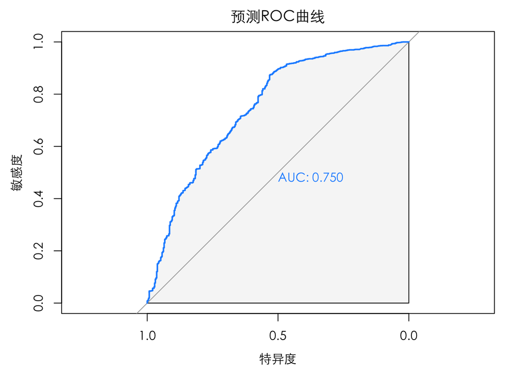

```r
# 绘制ROC曲线
par(family='STXihei')
plot(roc_glm, col = "dodgerblue", print.auc=TRUE,
     auc.polygon=TRUE, auc.polygon.col="#f6f6f6", main = "预测ROC曲线", xlim = c(1,0),
     xlab = "特异度",ylab = "敏感度")
```

使用is_ord作为因变量Y，自变量选择话题价格、话题价格带、想见行家用户数、行家约见人数、话题持续时长、话题所在城市、行家回复邀约的时长、行家接受约见的比率、话题长度、话题是否在北上广以及所属行业进行建模。

使用AIC进行模型选择，绘制ROC曲线如上。